# General Overview

I would like to thank you for taking the time to meet with me, and allowing me to showcase some of my skills and thought processes as I worked through the problems you presented to me. I am excited about the opportunity to work with you and your team, and I am confident that I can make a positive contribution to your organization. I am eager to discuss how I can help you achieve your goals, and how I can grow myself in the organization. Thank you again for your time and consideration.

## Technical Challenge 1

"Writing a SQL query to generate a cohort for the study. All patients in the study should have a diagnosis of Heart Failure (HF) or Cardiac Dysfunction and should have a lab result for Troponin at some point during their admission."

### Generation

The generation of the cohort needed to use multiple tables of information, as well as make sure that it contains content to be used for Technical Challenge 2 questions. The generation must use multiple tables in conjunction in order to properly output the required patients.

I touch upon the details in the next sections.

## Technical Challenge 2

We also need the retrospective data to do the analysis on. For this, we need observations every 12 hours for each of the patients in the cohort throughout the month of June 2000. For each of these observations, we need the following data

● The ratio of discharged patients over the previous 4 hours to the number of nurses in the patient’s unit

● The ratio of nurses to patients in the patient’s unit

● The patient’s latest Tropinin lab value

● The patient’s latest B-type natriuretic peptide (BNP) lab value

# Planning and Setup

### Set-up of repository

In the Repository I had a project board where I could keep track of the tasks that needed to be done and allocate them to different categories of primary and sub-tasks.

The README also methions where the walkthrough of the content is available. It also goes into starting up a virtual environment and installing the necessary dependencies in order to run this class cohort generator and generate these results.

# Functional & Class Imports

```python
# Within Notebook Imports
import pandas as pd
import matplotlib.pyplot as plt
import numpy as np
import os
import inspect
```

```python
# Class Imports
from cohort_builder import CohortBuilder
from logger import Logger

# Functional Imports
from pathlib import Path
```

```python
pd.set_option("display.max_rows", 1000)
pd.set_option("display.expand_frame_repr", True)
pd.set_option('display.width', 1000)
import warnings
warnings.filterwarnings("ignore", category=FutureWarning)
```

## Additional Support Classes

### Logging Class

I built a small support class, called Logger, that utilizes the python logging functionality. I prefer to use this over print statements in terminal for a few different reasons.

- It frees up terminal clutter
- It allows for comparison of multiple runs, if one needs to change parameters.
- It can seperate workflow processing in cases of automation.
- It provides a readable and parsable file for investigation efforts in the case of errors.

```python
print(inspect.getsource(Logger.__init__))
```

```
    def __init__(self, log_file: str) -> None:
        """Initializes the logger and ensures the log directory exists."""
        log_path = Path(log_file)
        log_path.parent.mkdir(parents=True, exist_ok=True)  # Ensure the Output directory exists

        self.logger = logging.getLogger(__name__)
        self.logger.setLevel(logging.INFO)

        # File handler to log messages to a file
        file_handler = logging.FileHandler(log_file)
        file_handler.setLevel(logging.INFO)

        # Formatter for log messages
        formatter = logging.Formatter("%(asctime)s - %(levelname)s - %(message)s")
        file_handler.setFormatter(formatter)

        # Add handler to logger (avoid duplicate handlers)
        if not self.logger.hasHandlers():
            self.logger.addHandler(file_handler)
```

```python
# Logger Pathing Information
#############################################################
# Define log directory and log file path
log_dir = os.path.abspath(os.path.join(os.getcwd(), os.pardir))
log_file = Path(log_dir + "processing_info.log")
# Remove existing log file if it exists
if log_file.exists():
    log_file.unlink()
    print(f"Removed existing log file: {log_file}")
```

```
Removed existing log file: d:\DataEngineerInterviewprocessing_info.log
```

# Cohort Generation

```python
db_path = os.path.abspath(os.path.join(os.getcwd(), os.pardir)) + "\\DE_Challenge_DB.sqlite"
cohort_builder = CohortBuilder(db_path, log_file=str(log_file))
```

## Investigation of Data

### Database Qualities

In order to get myself acquanted with the dataset, I first began with a general visual inspection of the dataset using VS Code and the SQLite plugin. This allowed me to peruse the datasets with table visuals, and write quick querys to generally subset and get a feel for the data.

I also wrote an investigastion function within my primary class of CohortGeneration. This function main purposes was to parse the various tables, and output summary information on the content, which included Primary/Foreign Keys that were already established in the database, as well as some infomration on missing or null values. It also gave me information of any rows that contained duplicate information.

Based on my investigation, there were no established primary keys, but I went forward under the assumption (and confirmed through my questions) that the name of columns across will be paired keys.

### A soiree into ICD9 Codes

In my inestigations with ICD9 Codes. I settled on a choce few codes that would be representative of the conditions of Heart Failure or Cardiac Dysfunction. While I do not know all the ICD9 codes, I think this was a good initial representation for the Cohort Generation. Also, the Query can be changed to accomodate additional or fewer ICD9 codes.

I settled on:

- Everything Under 425 --> Cardiomyopathy (and similar)
- Everything Under 428 --> Heart Failure (and similar)
- Code 4299 --> Unspecified Heart Disease
- Code 78551 --> Cardiogenic Shock

I also learned that "The National Center for Health Statistics (NCHS) and the Centers for Medicare and Medicaid Services are the U.S. governmental agencies responsible for overseeing all changes and modifications to the ICD-9-CM." Which makes me curious about their processes for very strange and hyper-specific codes.

# Generation of Dataset

## Generate patient Cohort

The generation of the cohort needed to use multiple tables of information, as well as make sure that it contains content to be used for Technical Challenge 2 questions. The generation must use multiple tables in conjunction in order to properly output the required patients.

I touch upon the details in the next sections.

### Query

```
WITH Discharges AS (
    -- Precompute the latest discharge date per patient to avoid redundant subqueries
    SELECT t.SUBJECT_ID, t.HADM_ID, MAX(t.INTIME) AS DISCHARGE_DATE
    FROM TRANSFERS t
    WHERE t.EVENTTYPE = 'discharge'
    GROUP BY t.SUBJECT_ID, t.HADM_ID
),
TroponinPatients AS (
    -- Get all patients who had at least one Troponin test during their admission
    SELECT DISTINCT l.SUBJECT_ID, l.HADM_ID
    FROM LABS l
    JOIN ICD_LABS il ON l.ITEMID = il.ITEMID
    WHERE il.LABEL LIKE '%Troponin%'
)
SELECT DISTINCT d.SUBJECT_ID, d.HADM_ID, d.ICD9_CODE, i.LONG_TITLE AS ICD_DESCRIPTION,
    t.CURR_CAREUNIT, DATETIME(t.INTIME) AS ADMISSION_DATE,
    DATETIME(ds.DISCHARGE_DATE) AS DISCHARGE_DATE
FROM DIAGNOSES d
LEFT JOIN ICD_DIAGNOSES i ON d.ICD9_CODE = i.ICD9_CODE
LEFT JOIN TRANSFERS t ON d.SUBJECT_ID = t.SUBJECT_ID AND d.HADM_ID = t.HADM_ID
LEFT JOIN Discharges ds ON d.SUBJECT_ID = ds.SUBJECT_ID AND d.HADM_ID = ds.HADM_ID
INNER JOIN TroponinPatients tp ON d.SUBJECT_ID = tp.SUBJECT_ID AND d.HADM_ID = tp.HADM_ID
WHERE (d.ICD9_CODE LIKE '428%' OR d.ICD9_CODE LIKE '425%' OR d.ICD9_CODE = '4299' OR d.ICD9_CODE = '78551')
AND t.EVENTTYPE = 'admit'
AND strftime('%Y-%m', t.INTIME) = '2000-06'
ORDER BY d.SUBJECT_ID, ADMISSION_DATE;
```

### Explaination of Query

This SQL query retrieves patients admitted in June 2000 with specific cardiovascular diagnoses who also had a Troponin test during their hospital stay.

Breakdown of Query Logic:

Discharges (WITH Discharges AS …)

- Precomputes the latest discharge date per patient admission from the TRANSFERS table.

Troponin Patients (WITH TroponinPatients AS …)

- Identifies patients with at least one Troponin test during admission.

Main Query:

- Retrieves diagnosis codes, descriptions, care unit, admission, and discharge dates.
- Joins DIAGNOSES, ICD_DIAGNOSES, TRANSFERS, and the precomputed tables.
- Filters:
- - Heart-related diagnoses (ICD9_CODE starts with 428, 425, or matches 4299, 78551).
- - Admissions only (EVENTTYPE = 'admit').
- - Patients admitted in June 2000 (strftime('%Y-%m', t.INTIME) = '2000-06').
- Sorts by patient ID and admission date.

Why This Approach?

- Efficiency: Uses WITH statements to avoid redundant subqueries.
- Specificity: Focuses on heart conditions + Troponin testing in a defined time window.
- Clarity: Ensures correct joins and structured filtering.

This query helps analyze Troponin testing in cardiac patients over a specific period.

The following function was used for patient generation (may be truncated in printing)

```python
print(inspect.getsource(cohort_builder.get_hf_patients))
```

```
    def get_hf_patients(self) -> pd.DataFrame:
        """Retrieve HF & Cardiac Dysfunction patients admitted in June 2000."""
        query = """
        WITH Discharges AS (
            -- Precompute the latest discharge date per patient to avoid redundant subqueries
            SELECT t.SUBJECT_ID, t.HADM_ID, MAX(t.INTIME) AS DISCHARGE_DATE
            FROM TRANSFERS t
            WHERE t.EVENTTYPE = 'discharge'
            GROUP BY t.SUBJECT_ID, t.HADM_ID
        ),
        TroponinPatients AS (
            -- Get all patients who had at least one Troponin test during their admission
            SELECT DISTINCT l.SUBJECT_ID, l.HADM_ID
            FROM LABS l
            JOIN ICD_LABS il ON l.ITEMID = il.ITEMID
            WHERE il.LABEL LIKE '%Troponin%'
        )
        SELECT DISTINCT d.SUBJECT_ID, d.HADM_ID, d.ICD9_CODE, i.LONG_TITLE AS ICD_DESCRIPTION,
            t.CURR_CAREUNIT, DATETIME(t.INTIME) AS ADMISSION_DATE,
            DATETIME(ds.DISCHARGE_DATE) AS DISCHARGE_DATE
        FROM DIAGNOSES d
        LEFT JOIN ICD_DIAGNOSES i ON d.ICD9_CODE = i.ICD9_CODE
        LEFT JOIN TRANSFERS t ON d.SUBJECT_ID = t.SUBJECT_ID AND d.HADM_ID = t.HADM_ID
        LEFT JOIN Discharges ds ON d.SUBJECT_ID = ds.SUBJECT_ID AND d.HADM_ID = ds.HADM_ID
        INNER JOIN TroponinPatients tp ON d.SUBJECT_ID = tp.SUBJECT_ID AND d.HADM_ID = tp.HADM_ID
        WHERE (d.ICD9_CODE LIKE '428%' OR d.ICD9_CODE LIKE '425%' OR d.ICD9_CODE = '4299' OR d.ICD9_CODE = '78551')
        AND t.EVENTTYPE = 'admit'
        AND strftime('%Y-%m', t.INTIME) = '2000-06'
        ORDER BY d.SUBJECT_ID, ADMISSION_DATE;
        """
        self.logger.info("\n Querying Database for HF/CD Patients Admitted in June 2000")
        df = pd.read_sql_query(query, self.conn)
        self.logger.info(f"\n Retrieved {len(df['SUBJECT_ID'].unique())} HF/CD patients admitted in June 2000")
        return df
```

```python
cohort_patients = cohort_builder.get_hf_patients()
```

```python
cohort_patients.head()
```

|  | SUBJECT_ID | HADM_ID | ICD9_CODE | ICD_DESCRIPTION | CURR_CAREUNIT | ADMISSION_DATE | DISCHARGE_DATE |
| --- | --- | --- | --- | --- | --- | --- | --- |
| 0 | 163 | 138528 | 4280 | Congestive heart failure, unspecified | CCU | 2000-06-20 04:54:06 | 2000-06-22 15:41:41 |
| 1 | 163 | 138528 | 42840 | Combined systolic and diastolic heart failure,... | CCU | 2000-06-20 04:54:06 | 2000-06-22 15:41:41 |
| 2 | 305 | 122211 | 4280 | Congestive heart failure, unspecified | MICU | 2000-06-19 23:50:45 | 2000-07-16 13:58:39 |
| 3 | 305 | 122211 | 42820 | Systolic heart failure, unspecified | MICU | 2000-06-19 23:50:45 | 2000-07-16 13:58:39 |
| 4 | 309 | 162308 | 42830 | Diastolic heart failure, unspecified | CCU | 2000-06-04 09:45:55 | 2000-06-06 14:48:27 |

The above function returns a patient dataframe, where each patient is separated by their admission, within the June timeframe, the assocaited ICD9 code and descirption, the care unit(s) is which they are being treated, as well as their admission start time ,and their discharge time.

## Generate Nurse Cohort

### Query

```
SELECT DISTINCT t.CURR_CAREUNIT, t.HADM_ID, n.CGID, c.LABEL,
        DATETIME(n.STARTTIME) AS STARTTIME, DATETIME(n.ENDTIME) AS ENDTIME
FROM TRANSFERS t
LEFT JOIN TREATMENT_TEAM n ON t.HADM_ID = n.HADM_ID
LEFT JOIN CARE_GIVERS c ON n.CGID = c.CGID
WHERE c.LABEL LIKE '%RN%';
```

### Explanation of Query

This SQL query retrieves nurse (RN) assignments for hospitalized patients by linking patient transfers with treatment teams.

Breakdown of Query Logic:

- FROM TRANSFERS (t)
- - Retrieves current care unit (CURR_CAREUNIT) and hospital admission ID (HADM_ID) from the TRANSFERS table.
- LEFT JOIN TREATMENT_TEAM (n)
- - Links patient admissions to caregivers (CGID) responsible for treatment.
- LEFT JOIN CARE_GIVERS (c)
- - Fetches caregiver role descriptions (LABEL), ensuring nurses ('%RN%') are selected.
- Filters (WHERE c.LABEL LIKE '%RN%')
- - Ensures only registered nurses (RN) are included.

Final Output:

- Returns care unit, hospital admission, caregiver ID, nurse role, and start/end times of their assignment.
- Uses DISTINCT to remove duplicate rows.

Why This Approach?

- Ensures relevant nurse data by filtering on RN roles.
- Efficiently joins caregiver details to patient admissions.
- Useful for analyzing nurse assignments per hospital stay and unit (hence the technical question)

The following function generates the nurse cohort for the selected patients:

```python
print(inspect.getsource(cohort_builder.get_nurses))
```

```
    def get_nurses(self) -> pd.DataFrame:
        """Retrieve all nurse assignments per unit."""
        query = """
        SELECT DISTINCT t.CURR_CAREUNIT, t.HADM_ID, n.CGID, c.LABEL,
               DATETIME(n.STARTTIME) AS STARTTIME, DATETIME(n.ENDTIME) AS ENDTIME
        FROM TRANSFERS t
        LEFT JOIN TREATMENT_TEAM n ON t.HADM_ID = n.HADM_ID
        LEFT JOIN CARE_GIVERS c ON n.CGID = c.CGID
        WHERE c.LABEL LIKE '%RN%';
        """
        self.logger.info("\n Querying Database for Nurse Assignments")
        df = pd.read_sql_query(query, self.conn)
        self.logger.info(f"\n Retrieved {len(df)} nurse assignments across units")
        return df
```

```python
nurse_assignments = cohort_builder.get_nurses()
```

```python
nurse_assignments.head()
```

|  | CURR_CAREUNIT | HADM_ID | CGID | LABEL | STARTTIME | ENDTIME |
| --- | --- | --- | --- | --- | --- | --- |
| 0 | MICU | 174105 | 18565.0 | RN | 2000-06-13 19:00:00 | 2000-06-14 07:00:00 |
| 1 | None | 174105 | 18565.0 | RN | 2000-06-13 19:00:00 | 2000-06-14 07:00:00 |
| 2 | NICU | 135750 | 16433.0 | RN | 2000-06-18 07:00:00 | 2000-06-18 19:00:00 |
| 3 | NICU | 135750 | 19296.0 | RN | 2000-06-17 19:00:00 | 2000-06-18 07:00:00 |
| 4 | NICU | 135750 | 20809.0 | RN | 2000-06-18 19:00:00 | 2000-06-19 07:00:00 |

The above table returns Nurses during this time frame, thier Title, Care Giver ID, Hopsital Admin ID, along with the unit that they are assigned to with start and end times. This will provide us with the information needed to calcualte or rations is Challenge 2.

# Data Analysis

## Incorporate Time Blocking

One of the things that I chose to conduct in this processing, is to incorporate infomration of Time blocking. Technical Challenge 2 asks for 12 hour chunks, but also 4 hr blocks within those chunks. For easier assignment and counting, I wrote a function that would expand both the patient and nurse time blocking allocations so we know which unit per time block they are assigned to. It is an upfront computation, but it allows for quicker filtering and grouping later on for various questions we could ask.

```python
print(inspect.getsource(cohort_builder.generate_time_blocks))
```

```
    def generate_time_blocks(self, patients_df: pd.DataFrame, nurses_df: pd.DataFrame) -> tuple:
        """
        Expands each patient’s admission period and each nurse’s shift into 12-hour time blocks,
        with nested 4-hour sub-blocks. Retains admission (`INTIME`) and discharge (`DISCHARGE_DATE`) times.

        Parameters:
        - patients_df (pd.DataFrame): DataFrame containing patient admissions, with columns:
            - SUBJECT_ID (int)
            - HADM_ID (int)
            - CURR_CAREUNIT (str)
            - ADMISSION_DATE (datetime) [Previously `INTIME`]
            - DISCHARGE_DATE (datetime)
        - nurses_df (pd.DataFrame): DataFrame containing nurse shift data, with columns:
            - CGID (int) - Nurse ID
            - CURR_CAREUNIT (str) - Unit the nurse worked in
            - STARTTIME (datetime) - Shift start time
            - ENDTIME (datetime) - Shift end time

        Returns:
        - tuple(pd.DataFrame, pd.DataFrame):
            - Expanded patient DataFrame with **12-hour and 4-hour time blocks, keeping `ADMISSION_DATE` and `DISCHARGE_DATE`**.
            - Expanded nurse DataFrame with **12-hour and 4-hour time blocks**.
        """
        self.logger.info("\n Generating 12-hour Time Blocks for Patients and Nurses")
        # Ensure proper datetime format
        patients_df["ADMISSION_DATE"] = pd.to_datetime(patients_df["ADMISSION_DATE"])
        patients_df["DISCHARGE_DATE"] = pd.to_datetime(patients_df["DISCHARGE_DATE"])
        nurses_df["STARTTIME"] = pd.to_datetime(nurses_df["STARTTIME"])
        nurses_df["ENDTIME"] = pd.to_datetime(nurses_df["ENDTIME"])

        # Generate all 12-hour blocks in June 2000
        start_time = datetime(2000, 6, 1, 0, 0)
        end_time = datetime(2000, 6, 30, 23, 59)
        twelve_hour_blocks = [start_time + timedelta(hours=12 * i) for i in range((end_time - start_time).days * 2 + 1)]

        # Define the 4-hour sub-block offsets relative to each 12-hour block
        sub_block_offsets = [timedelta(hours=0), timedelta(hours=4), timedelta(hours=8)]

        expanded_patient_rows = []
        expanded_nurse_rows = []
```

[output cut: 35 more lines]

```
        # Create DataFrames
        expanded_patients_df = pd.DataFrame(expanded_patient_rows, columns=[
            "SUBJECT_ID", "HADM_ID", "CURR_CAREUNIT", "TIME_BLOCK_12HR", "TIME_BLOCK_4HR", "ADMISSION_DATE", "DISCHARGE_DATE"
        ])

        expanded_nurses_df = pd.DataFrame(expanded_nurse_rows, columns=[
            "CGID", "CURR_CAREUNIT", "TIME_BLOCK_12HR", "TIME_BLOCK_4HR"
        ])

        self.logger.info("\n Successfully Generated 12-hour Time Blocks for Patients and Nurses")
        self.logger.info(f"\n Generated {len(expanded_patients_df)} time-block entries for {patients_df.shape[0]} patients.")
        self.logger.info(f"\n Generated {len(expanded_nurses_df)} time-block entries for {nurses_df.shape[0]} nurses.")


        return expanded_patients_df, expanded_nurses_df
```

```python
expanded_patients_df, expanded_nurses_df = cohort_builder.generate_time_blocks(cohort_patients, nurse_assignments)
```

```python
expanded_patients_df.head()
```

|  | SUBJECT_ID | HADM_ID | CURR_CAREUNIT | TIME_BLOCK_12HR | TIME_BLOCK_4HR | ADMISSION_DATE | DISCHARGE_DATE |
| --- | --- | --- | --- | --- | --- | --- | --- |
| 0 | 163 | 138528 | CCU | 2000-06-20 12:00:00 | 2000-06-20 12:00:00 | 2000-06-20 04:54:06 | 2000-06-22 15:41:41 |
| 1 | 163 | 138528 | CCU | 2000-06-20 12:00:00 | 2000-06-20 16:00:00 | 2000-06-20 04:54:06 | 2000-06-22 15:41:41 |
| 2 | 163 | 138528 | CCU | 2000-06-20 12:00:00 | 2000-06-20 20:00:00 | 2000-06-20 04:54:06 | 2000-06-22 15:41:41 |
| 3 | 163 | 138528 | CCU | 2000-06-21 00:00:00 | 2000-06-21 00:00:00 | 2000-06-20 04:54:06 | 2000-06-22 15:41:41 |
| 4 | 163 | 138528 | CCU | 2000-06-21 00:00:00 | 2000-06-21 04:00:00 | 2000-06-20 04:54:06 | 2000-06-22 15:41:41 |

```python
expanded_nurses_df.head()
```

|  | CGID | CURR_CAREUNIT | TIME_BLOCK_12HR | TIME_BLOCK_4HR |
| --- | --- | --- | --- | --- |
| 0 | 18565.0 | MICU | 2000-06-14 | 2000-06-14 00:00:00 |
| 1 | 18565.0 | MICU | 2000-06-14 | 2000-06-14 04:00:00 |
| 2 | 18565.0 | MICU | 2000-06-14 | 2000-06-14 08:00:00 |
| 3 | 18565.0 | None | 2000-06-14 | 2000-06-14 00:00:00 |
| 4 | 18565.0 | None | 2000-06-14 | 2000-06-14 04:00:00 |

As we can see above, there is a Time block expansion, for both 12 and 4 hours per patient and per caregiver.

## Discharge to Nurse Ratio

```python
print(inspect.getsource(cohort_builder.compute_discharge_to_nurse_ratio))
```

```
    def compute_discharge_to_nurse_ratio(self, patients_df: pd.DataFrame, nurses_df: pd.DataFrame) -> pd.DataFrame:
        """
        Computes the discharge-to-nurse ratio for each 12-hour block using pre-generated 4-hour sub-blocks.

        Parameters:
        - patients_df (pd.DataFrame): Expanded patient DataFrame with `TIME_BLOCK_12HR` and `TIME_BLOCK_4HR`, including:
            - SUBJECT_ID, HADM_ID, CURR_CAREUNIT, TIME_BLOCK_12HR, TIME_BLOCK_4HR, ADMISSION_DATE, DISCHARGE_DATE
        - nurses_df (pd.DataFrame): Expanded nurse DataFrame with `TIME_BLOCK_12HR` and `TIME_BLOCK_4HR`.

        Returns:
        - pd.DataFrame: DataFrame with discharge-to-nurse ratio metrics for each 12-hour block.
        """
        self.logger.info("\n Computing Discharge-to-Nurse Ratio for 12-hour Blocks using 4-hour Sub-blocks")
        # Ensure all date columns are in datetime format
        patients_df["TIME_BLOCK_12HR"] = pd.to_datetime(patients_df["TIME_BLOCK_12HR"])
        patients_df["TIME_BLOCK_4HR"] = pd.to_datetime(patients_df["TIME_BLOCK_4HR"])
        patients_df["DISCHARGE_DATE"] = pd.to_datetime(patients_df["DISCHARGE_DATE"])
        nurses_df["TIME_BLOCK_12HR"] = pd.to_datetime(nurses_df["TIME_BLOCK_12HR"])
        nurses_df["TIME_BLOCK_4HR"] = pd.to_datetime(nurses_df["TIME_BLOCK_4HR"])

        # Identify the first 4-hour block in which each patient was discharged (within the correct 12-hour period)
        patients_df["DISCHARGE_TIME_BLOCK"] = patients_df.groupby(["SUBJECT_ID", "HADM_ID", "TIME_BLOCK_12HR"])["TIME_BLOCK_4HR"].transform(
            lambda x: x[x >= patients_df.loc[x.index, "DISCHARGE_DATE"]].min()
        )

        # Count discharges per unit per 4-hour sub-block (only counting each patient once within the 12-hour period)
        discharges = (
            patients_df[patients_df["TIME_BLOCK_4HR"] == patients_df["DISCHARGE_TIME_BLOCK"]]
            .groupby(["CURR_CAREUNIT", "TIME_BLOCK_12HR", "TIME_BLOCK_4HR"])
            .size()
            .reset_index(name="num_discharged")
        )

        # Count nurses per unit per 4-hour sub-block
        nurses = (
            nurses_df
            .groupby(["CURR_CAREUNIT", "TIME_BLOCK_12HR", "TIME_BLOCK_4HR"])
            .size()
            .reset_index(name="num_nurses")
        )
```

[output cut: 29 more lines]

```
            .reset_index()
        )

        # Compute the final averaged ratio across all 3 sub-blocks
        summary_df["AVG_DISCHARGE_TO_NURSE_RATIO"] = summary_df[
            ["DISCHARGE_NURSE_RATIO_4HR_1", "DISCHARGE_NURSE_RATIO_4HR_2", "DISCHARGE_NURSE_RATIO_4HR_3"]
        ].mean(axis=1)

        summary_df["AVG_UNIT_NORM_RATIO"] = summary_df[
            ["UNIT_NORM_RATIO_4HR_1", "UNIT_NORM_RATIO_4HR_2", "UNIT_NORM_RATIO_4HR_3"]
        ].mean(axis=1)

        self.logger.info("\n Successfully Computed Discharge-to-Nurse Ratio for 12-hour Blocks using 4-hour Sub-blocks")
        self.logger.info(f"\n Computed discharge-to-nurse ratio for {summary_df.shape[0]} 12-hour blocks.")
        return summary_df
```

```python
discharge_ratio = cohort_builder.compute_discharge_to_nurse_ratio(expanded_patients_df, expanded_nurses_df)
```

```python
discharge_ratio.iloc[10:16]
```

|  | CURR_CAREUNIT | TIME_BLOCK_12HR | DISCHARGE_4HR_1 | DISCHARGE_4HR_2 | DISCHARGE_4HR_3 | NURSES_4HR_1 | NURSES_4HR_2 | NURSES_4HR_3 | DISCHARGE_NURSE_RATIO_4HR_1 | DISCHARGE_NURSE_RATIO_4HR_2 | DISCHARGE_NURSE_RATIO_4HR_3 | UNIT_NORM_RATIO_4HR_1 | UNIT_NORM_RATIO_4HR_2 | UNIT_NORM_RATIO_4HR_3 | AVG_DISCHARGE_TO_NURSE_RATIO | AVG_UNIT_NORM_RATIO |
| --- | --- | --- | --- | --- | --- | --- | --- | --- | --- | --- | --- | --- | --- | --- | --- | --- |
| 10 | CCU | 2000-06-06 00:00:00 | 0.0 | 2.0 | 0.0 | 67 | 67 | 67 | 0.0 | 0.029851 | 0.00000 | 0.0 | 2.348226 | 0.000000 | 0.009950 | 0.782742 |
| 11 | CCU | 2000-06-06 12:00:00 | 0.0 | 1.0 | 0.0 | 61 | 61 | 61 | 0.0 | 0.016393 | 0.00000 | 0.0 | 1.289599 | 0.000000 | 0.005464 | 0.429866 |
| 12 | CCU | 2000-06-07 00:00:00 | 0.0 | 0.0 | 0.0 | 77 | 77 | 77 | 0.0 | 0.000000 | 0.00000 | 0.0 | 0.000000 | 0.000000 | 0.000000 | 0.000000 |
| 13 | CCU | 2000-06-07 12:00:00 | 0.0 | 0.0 | 2.0 | 64 | 64 | 64 | 0.0 | 0.000000 | 0.03125 | 0.0 | 0.000000 | 2.458299 | 0.010417 | 0.819433 |
| 14 | CCU | 2000-06-08 00:00:00 | 0.0 | 0.0 | 0.0 | 65 | 65 | 65 | 0.0 | 0.000000 | 0.00000 | 0.0 | 0.000000 | 0.000000 | 0.000000 | 0.000000 |
| 15 | CCU | 2000-06-08 12:00:00 | 0.0 | 3.0 | 0.0 | 69 | 69 | 69 | 0.0 | 0.043478 | 0.00000 | 0.0 | 3.420242 | 0.000000 | 0.014493 | 1.140081 |

The above table shows for our care unit of interest, within a given 12 hr time chunk, the changes in discharge per 4 hr blocks, and nurse assignment changes if any. We get ratio values per block as well as an average over the 12 hr period.

## Patient to Nurse Ratio

```python
print(inspect.getsource(cohort_builder.compute_nurse_to_patient_ratio))
```

```
    def compute_nurse_to_patient_ratio(self, patients_df: pd.DataFrame, nurses_df: pd.DataFrame) -> pd.DataFrame:
        """
        Computes the nurse-to-patient ratio for each 12-hour block using pre-generated 4-hour sub-blocks.

        Parameters:
        - patients_df (pd.DataFrame): Expanded patient DataFrame with `TIME_BLOCK_12HR` and `TIME_BLOCK_4HR`, including:
            - SUBJECT_ID, HADM_ID, CURR_CAREUNIT, TIME_BLOCK_12HR, TIME_BLOCK_4HR, ADMISSION_DATE, DISCHARGE_DATE
        - nurses_df (pd.DataFrame): Expanded nurse DataFrame with `TIME_BLOCK_12HR` and `TIME_BLOCK_4HR`.

        Returns:
        - pd.DataFrame: DataFrame with nurse-to-patient ratio metrics for each 12-hour block.
        """
        self.logger.info("\n Computing Nurse-to-Patient Ratio for 12-hour Blocks using 4-hour Sub-blocks")
        # Ensure all date columns are in datetime format
        patients_df["TIME_BLOCK_12HR"] = pd.to_datetime(patients_df["TIME_BLOCK_12HR"])
        patients_df["TIME_BLOCK_4HR"] = pd.to_datetime(patients_df["TIME_BLOCK_4HR"])
        patients_df["DISCHARGE_DATE"] = pd.to_datetime(patients_df["DISCHARGE_DATE"])
        nurses_df["TIME_BLOCK_12HR"] = pd.to_datetime(nurses_df["TIME_BLOCK_12HR"])
        nurses_df["TIME_BLOCK_4HR"] = pd.to_datetime(nurses_df["TIME_BLOCK_4HR"])

        # Count the total number of patients per unit per 4-hour sub-block
        patients_in_unit = (
            patients_df[
                (patients_df["TIME_BLOCK_4HR"] >= patients_df["ADMISSION_DATE"]) &
                (patients_df["TIME_BLOCK_4HR"] < patients_df["DISCHARGE_DATE"])
            ]
            .groupby(["CURR_CAREUNIT", "TIME_BLOCK_12HR", "TIME_BLOCK_4HR"])
            .size()
            .reset_index(name="num_patients")
        )

        # Count the number of nurses per unit per 4-hour sub-block
        nurses_in_unit = (
            nurses_df
            .groupby(["CURR_CAREUNIT", "TIME_BLOCK_12HR", "TIME_BLOCK_4HR"])
            .size()
            .reset_index(name="num_nurses")
        )

        # Merge patient and nurse counts
```

[output cut: 29 more lines]

```
            .reset_index()
        )

        # Compute the final averaged ratio across all 3 sub-blocks
        summary_df["AVG_NURSE_TO_PATIENT_RATIO"] = summary_df[
            ["NURSE_TO_PATIENT_RATIO_4HR_1", "NURSE_TO_PATIENT_RATIO_4HR_2", "NURSE_TO_PATIENT_RATIO_4HR_3"]
        ].mean(axis=1)

        summary_df["AVG_UNIT_NORM_RATIO"] = summary_df[
            ["UNIT_NORM_RATIO_4HR_1", "UNIT_NORM_RATIO_4HR_2", "UNIT_NORM_RATIO_4HR_3"]
        ].mean(axis=1)

        self.logger.info("\n Successfully Computed Nurse-to-Patient Ratio for 12-hour Blocks using 4-hour Sub-blocks")
        self.logger.info(f"\n Computed nurse-to-patient ratio for {summary_df.shape[0]} 12-hour blocks.")
        return summary_df
```

```python
patient_ratio = cohort_builder.compute_nurse_to_patient_ratio(expanded_patients_df, expanded_nurses_df)
```

```python
patient_ratio.head()
```

|  | CURR_CAREUNIT | TIME_BLOCK_12HR | PATIENTS_4HR_1 | PATIENTS_4HR_2 | PATIENTS_4HR_3 | NURSES_4HR_1 | NURSES_4HR_2 | NURSES_4HR_3 | NURSE_TO_PATIENT_RATIO_4HR_1 | NURSE_TO_PATIENT_RATIO_4HR_2 | NURSE_TO_PATIENT_RATIO_4HR_3 | UNIT_NORM_RATIO_4HR_1 | UNIT_NORM_RATIO_4HR_2 | UNIT_NORM_RATIO_4HR_3 | AVG_NURSE_TO_PATIENT_RATIO | AVG_UNIT_NORM_RATIO |
| --- | --- | --- | --- | --- | --- | --- | --- | --- | --- | --- | --- | --- | --- | --- | --- | --- |
| 0 | CCU | 2000-06-01 00:00:00 | 1.0 | 1.0 | 1.0 | 70 | 70 | 70 | 70.000000 | 70.000000 | 70.000000 | 23.527808 | 23.527808 | 23.527808 | 70.000000 | 23.527808 |
| 1 | CCU | 2000-06-01 12:00:00 | 3.0 | 3.0 | 3.0 | 63 | 63 | 63 | 21.000000 | 21.000000 | 21.000000 | 7.058343 | 7.058343 | 7.058343 | 21.000000 | 7.058343 |
| 2 | CCU | 2000-06-02 00:00:00 | 10.0 | 10.0 | 10.0 | 63 | 63 | 63 | 6.300000 | 6.300000 | 6.300000 | 2.117503 | 2.117503 | 2.117503 | 6.300000 | 2.117503 |
| 3 | CCU | 2000-06-02 12:00:00 | 18.0 | 18.0 | 18.0 | 61 | 61 | 61 | 3.388889 | 3.388889 | 3.388889 | 1.139045 | 1.139045 | 1.139045 | 3.388889 | 1.139045 |
| 4 | CCU | 2000-06-03 00:00:00 | 19.0 | 19.0 | 19.0 | 64 | 64 | 64 | 3.368421 | 3.368421 | 3.368421 | 1.132165 | 1.132165 | 1.132165 | 3.368421 | 1.132165 |

The above table shows for our care unit of interest, within a given 12 hr time chunk, the changes in patients per 4 hr blocks, and nurse assignment changes if any. We get ratio values per block as well as an average over the 12 hr period. If there are 0 patients, it is set to a vlaue of 1, so that there is no divide by 0 error. This avoids points that look like they have equivalent amount of nurses to patients.

## Subset Labs for Cohort Patients only

Because the Labs file is so large, containing all the patients and all their labs, multiple even, over a large time frame, it is best we subset it moving forward in the analysis just to make things more managable and specific to our cohort of patients.?

```python
print(inspect.getsource(cohort_builder.subset_labs_for_cohort))
```

```
    def subset_labs_for_cohort(self, patients_df: pd.DataFrame) -> pd.DataFrame:
        """
        Subsets the `LABS` table to only include Troponin & BNP tests for patients in the cohort,
        ensuring that test results are assigned to the correct admission.

        Parameters:
        - db_conn (sqlite3.Connection): Database connection to execute SQL queries.
        - patients_df (pd.DataFrame): Cohort patient DataFrame, including:
            - SUBJECT_ID, HADM_ID, ADMISSION_DATE, DISCHARGE_DATE

        Returns:
        - pd.DataFrame: Filtered lab results for cohort patients, including:
            - SUBJECT_ID, HADM_ID, ITEMID, CHARTTIME, VALUENUM, VALUEUOFM, LABEL (from ICD_LABS)
        """
        self.logger.info("\n Subsetting Troponin & BNP Tests for Cohort Patients")

        # Convert HADM_IDs to a plain Python list of integers
        hadm_ids = list(map(int, patients_df["HADM_ID"].unique()))  # Avoid np.int64 issues

        # If too many HADM_IDs, split into chunks (SQLite IN limit is around 999)
        chunk_size = 500  # Safe limit
        hadm_id_chunks = [hadm_ids[i:i + chunk_size] for i in range(0, len(hadm_ids), chunk_size)]

        # Initialize empty DataFrame to store results
        labs_subset_df = pd.DataFrame()

        # Loop through chunks and execute separate queries
        for chunk in hadm_id_chunks:
            query = f"""
            SELECT l.SUBJECT_ID, l.HADM_ID, l.ITEMID, l.CHARTTIME, l.VALUENUM, l.VALUEUOM, il.LABEL
            FROM LABS l
            JOIN ICD_LABS il ON l.ITEMID = il.ITEMID
            WHERE (il.LABEL LIKE '%Troponin%' OR il.LABEL LIKE '%BNP%')
            AND l.HADM_ID IN ({','.join(['?']*len(chunk))})
            """

            # Fetch data from SQL using parameterized query
            chunk_df = pd.read_sql_query(query, self.conn, params=chunk)

            # Append to the main DataFrame
            labs_subset_df = pd.concat([labs_subset_df, chunk_df], ignore_index=True)

        # Ensure CHARTTIME is in datetime format
        labs_subset_df["CHARTTIME"] = pd.to_datetime(labs_subset_df["CHARTTIME"])

        # Merge with patients_df to get admission and discharge dates
        labs_subset_df = labs_subset_df.merge(
            patients_df[["SUBJECT_ID", "HADM_ID", "ADMISSION_DATE", "DISCHARGE_DATE"]],
            on=["SUBJECT_ID", "HADM_ID"],
            how="inner"
        )

        # Keep only lab results within the correct admission period
        labs_subset_df = labs_subset_df[
            (labs_subset_df["CHARTTIME"] >= labs_subset_df["ADMISSION_DATE"]) &
            (labs_subset_df["CHARTTIME"] < labs_subset_df["DISCHARGE_DATE"])
        ]


        self.logger.info("\n Successfully Subsetting Troponin & BNP Tests for Cohort Patients")
        self.logger.info(f"\n Loaded {labs_subset_df.shape[0]} Troponin & BNP test results for cohort patients.")
        return labs_subset_df
```

```python
labs_df = cohort_builder.subset_labs_for_cohort(cohort_patients)
```

```python
labs_df.head()
```

|  | SUBJECT_ID | HADM_ID | ITEMID | CHARTTIME | VALUENUM | VALUEUOM | LABEL | ADMISSION_DATE | DISCHARGE_DATE |
| --- | --- | --- | --- | --- | --- | --- | --- | --- | --- |
| 2 | 163 | 138528.0 | 51003 | 2000-06-21 04:00:00 | 0.44 | ng/ml | Troponin T | 2000-06-20 04:54:06 | 2000-06-22 15:41:41 |
| 3 | 163 | 138528.0 | 51003 | 2000-06-21 04:00:00 | 0.44 | ng/ml | Troponin T | 2000-06-20 04:54:06 | 2000-06-22 15:41:41 |
| 8 | 309 | 162308.0 | 51003 | 2000-06-04 14:11:00 | NaN | ng/mL | Troponin T | 2000-06-04 09:45:55 | 2000-06-06 14:48:27 |
| 9 | 309 | 162308.0 | 51003 | 2000-06-04 20:04:00 | 0.20 | ng/mL | Troponin T | 2000-06-04 09:45:55 | 2000-06-06 14:48:27 |
| 10 | 309 | 162308.0 | 51003 | 2000-06-05 02:04:00 | 0.34 | ng/mL | Troponin T | 2000-06-04 09:45:55 | 2000-06-06 14:48:27 |

The table gives us the Subject IDs of our cohort, and their labs, if they have any recorded. This also returns the value of the lab, the type of lab ordered, and when the lab was completed. Alongside, I also include the patients admssion and discharge date, so we can see at what point the lab was ordered during their admission. If a patient has multiple labs throughout their admission, we will be able to track and get the most up to date lab, which is relevant in the next sections.

## Collect Continous Lab results for Patient Per admission

```python
print(inspect.getsource(cohort_builder.compute_latest_lab_test))
```

```
    def compute_latest_lab_test(self, patients_df: pd.DataFrame, labs_subset_df: pd.DataFrame, test_name: str, value_col_prefix: str) -> pd.DataFrame:
        """
        Retrieves the most recent lab test values per patient per 4-hour block,
        aggregates to find the latest per 12-hour block, and fills forward if no new test exists.

        Parameters:
        - patients_df (pd.DataFrame): DataFrame containing patient time blocks.
        - labs_subset_df (pd.DataFrame): DataFrame containing lab test results.
        - test_name (str): The name (or substring) of the test to filter (e.g., "Troponin" or "BNP").
        - value_col_prefix (str): The prefix for renaming value columns (e.g., "TROPONIN" or "BNP").

        Returns:
        - pd.DataFrame: DataFrame with latest test values per 12-hour block.
        """
        self.logger.info(f"\n Computing Latest {test_name} Values for 12-hour Blocks for Cohort Patients")

        # Ensure datetime format
        patients_df["TIME_BLOCK_12HR"] = pd.to_datetime(patients_df["TIME_BLOCK_12HR"])
        patients_df["TIME_BLOCK_4HR"] = pd.to_datetime(patients_df["TIME_BLOCK_4HR"])
        labs_subset_df["CHARTTIME"] = pd.to_datetime(labs_subset_df["CHARTTIME"])

        # Filter only relevant tests
        test_df = labs_subset_df[labs_subset_df["LABEL"].str.contains(test_name, case=False, na=False)]

        # Merge with patients to get all time blocks
        test_df = patients_df.merge(
            test_df,
            on=["SUBJECT_ID", "HADM_ID"],
            how="left"
        )

        # Keep only tests within their corresponding 4-hour block
        test_df = test_df[
            (test_df["CHARTTIME"] >= test_df["TIME_BLOCK_4HR"]) &
            (test_df["CHARTTIME"] < test_df["TIME_BLOCK_4HR"] + pd.Timedelta(hours=4))
        ]

        # Get the latest test per 4-hour block
        latest_4hr_test = (
            test_df.sort_values(["SUBJECT_ID", "HADM_ID", "TIME_BLOCK_4HR", "CHARTTIME"])
```

[output cut: 18 more lines]

```
            .ffill()
        )

        # Aggregate to 12-hour summary
        summary_df = (
            patients_with_test
            .sort_values(["SUBJECT_ID", "HADM_ID", "TIME_BLOCK_12HR", "TIME_BLOCK_4HR"])
            .groupby(["SUBJECT_ID", "HADM_ID", "TIME_BLOCK_12HR"])
            .last()[[f"{value_col_prefix}_VAL", f"{value_col_prefix}_UNIT"]]
            .reset_index()
        )

        self.logger.info(f"\n Computed latest {test_name} values for {summary_df.shape[0]} 12-hour blocks.")

        return summary_df
```

```python
lab_results_troponin = cohort_builder.compute_latest_lab_test(expanded_patients_df, labs_df, test_name="Troponin", value_col_prefix="TROPONIN")
```

```python
lab_results_bnp = cohort_builder.compute_latest_lab_test(expanded_patients_df, labs_df, test_name="BNP", value_col_prefix="BNP")
```

```python
lab_results_troponin.head()
```

|  | SUBJECT_ID | HADM_ID | TIME_BLOCK_12HR | TROPONIN_VAL | TROPONIN_UNIT |
| --- | --- | --- | --- | --- | --- |
| 0 | 163 | 138528 | 2000-06-20 12:00:00 | NaN | None |
| 1 | 163 | 138528 | 2000-06-21 00:00:00 | 0.44 | ng/ml |
| 2 | 163 | 138528 | 2000-06-21 12:00:00 | 0.44 | ng/ml |
| 3 | 163 | 138528 | 2000-06-22 00:00:00 | 0.44 | ng/ml |
| 4 | 163 | 138528 | 2000-06-22 12:00:00 | 0.44 | ng/ml |

## Grab Latest result for each Patient in Cohort

```python
print(inspect.getsource(cohort_builder.get_latest_test_per_patient))
```

```
    def get_latest_test_per_patient(self, patients_df: pd.DataFrame, test_df: pd.DataFrame, test_column: str, unit_column: str) -> pd.DataFrame:
        """
        Retrieves the most recent test value (Troponin or BNP) for each patient,
        considering only their latest hospital admission.

        Parameters:
        - patients_df (pd.DataFrame): The full cohort DataFrame, including all admissions.
        - test_df (pd.DataFrame): The test-specific DataFrame (either Troponin or BNP summary).
        - test_column (str): Column name for the test value (e.g., "TROPONIN_VAL" or "BNP_VAL").
        - unit_column (str): Column name for the test unit (e.g., "TROPONIN_UNIT" or "BNP_UNIT").

        Returns:
        - pd.DataFrame: DataFrame containing the latest test value per patient.
        """
        self.logger.info(f"\n Retrieving Latest {test_column} Values for Patients")

        # Ensure date format
        patients_df["ADMISSION_DATE"] = pd.to_datetime(patients_df["ADMISSION_DATE"])
        test_df["TIME_BLOCK_12HR"] = pd.to_datetime(test_df["TIME_BLOCK_12HR"])

        # Get the most recent admission per patient
        latest_admissions = (
            patients_df.sort_values(["SUBJECT_ID", "ADMISSION_DATE"], ascending=[True, False])
            .drop_duplicates(subset=["SUBJECT_ID"], keep="first")  # Keep latest admission
            .loc[:, ["SUBJECT_ID", "HADM_ID", "ADMISSION_DATE"]]
        )

        # Merge latest admissions with the test dataset
        latest_tests = latest_admissions.merge(
            test_df,
            on=["SUBJECT_ID", "HADM_ID"],
            how="left"
        )

        # Get the latest test result per patient (most recent time block)
        latest_tests = (
            latest_tests.sort_values(["SUBJECT_ID", "TIME_BLOCK_12HR"], ascending=[True, False])
            .drop_duplicates(subset=["SUBJECT_ID"], keep="first")  # Keep latest test result
            .loc[:, ["SUBJECT_ID", test_column, unit_column]]
        )

        self.logger.info(f"\n [INFO] Retrieved latest {test_column} values for {latest_tests.shape[0]} patients.")

        return latest_tests
```

```python
latest_troponin = cohort_builder.get_latest_test_per_patient(expanded_patients_df, lab_results_troponin, "TROPONIN_VAL", "TROPONIN_UNIT")
```

```python
latest_bnp = cohort_builder.get_latest_test_per_patient(expanded_patients_df, lab_results_bnp, "BNP_VAL", "BNP_UNIT")
```

```python
latest_troponin.head()
```

|  | SUBJECT_ID | TROPONIN_VAL | TROPONIN_UNIT |
| --- | --- | --- | --- |
| 4 | 163 | 0.44 | ng/ml |
| 25 | 305 | 0.03 | ng/mL |
| 30 | 309 | 0.25 | ng/mL |
| 47 | 318 | 19.90 | ng/ml |
| 52 | 353 | NaN | None |

```python
# Single Subject Example
latest_troponin[latest_troponin['SUBJECT_ID'] == 4155]
```

|  | SUBJECT_ID | TROPONIN_VAL | TROPONIN_UNIT |
| --- | --- | --- | --- |
| 933 | 4155 | 0.06 | ng/mL |

```python
# Single Subject Example
latest_bnp[latest_bnp['SUBJECT_ID'] == 4155]
```

|  | SUBJECT_ID | BNP_VAL | BNP_UNIT |
| --- | --- | --- | --- |
| 933 | 4155 | 2536.0 | pg/mL |

I wrote a function that takes in the expanded data table and then only subset to the most recent Troponin value, or any lab value that is available for the patient in our cohort. Any none values show that the patient did not have a (Troponin or BNP) lab ordered during thier admission.

## Content Visuals

```python
from cohort_visualizer import CohortVisualizer
base_save = os.path.abspath(os.path.join(os.getcwd(), os.pardir)) + "\\Output\\"
```

### Dischage Ratio Plots

As for visuals, I am starting too look as the discharge calulcations over the 12 and 4 hr time blocks. In the first plot, I am showing the raw ratio values, which can be insightful. However, it is important to note that if we are also concerned about looking at different units, we would want to look at the unit normalized values. For example, There may be units with a few nurse and a fuw discharges, but that would look very different from a unit that has twice as many discharges, but three times as many nurses. It gives a better understanding cross unit. It also makes sense that most our discharges that we see are a part of the CCU (Coronary Care Unit) since our cohort is filtered for Heart Issues. ALongside the MICU (Medical Intensive Care Unit). With SICU (Surgical Intensive Care Unit) and TSICU (Trauma Surgical Intensive Care Unit) both following similarly in discharges, but at a lower rate.

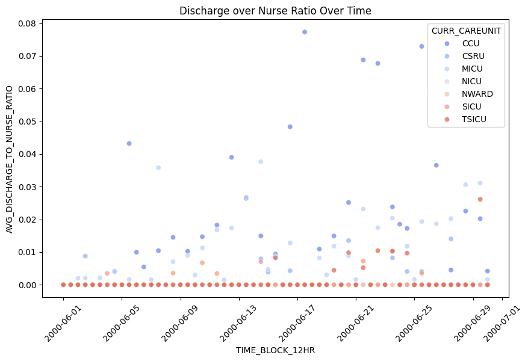

```python
CohortVisualizer.scatter_plot(
    df=discharge_ratio,
    x="TIME_BLOCK_12HR",
    y="AVG_DISCHARGE_TO_NURSE_RATIO",
    hue="CURR_CAREUNIT",
    title="Discharge over Nurse Ratio Over Time",
    save_path=base_save+"Discharge_Nurse_Ratio.png"
)
```

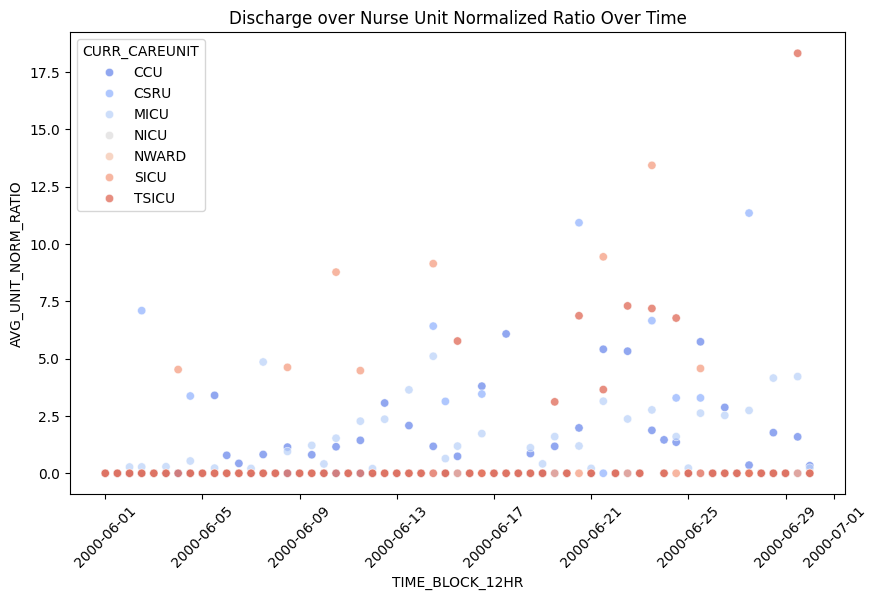

```python
CohortVisualizer.scatter_plot(
    df=discharge_ratio,
    x="TIME_BLOCK_12HR",
    y="AVG_UNIT_NORM_RATIO",
    hue="CURR_CAREUNIT",
    title="Discharge over Nurse Unit Normalized Ratio Over Time",
    save_path=base_save+"Discharge_Nurse_Ratio_Norm.png"
)
```

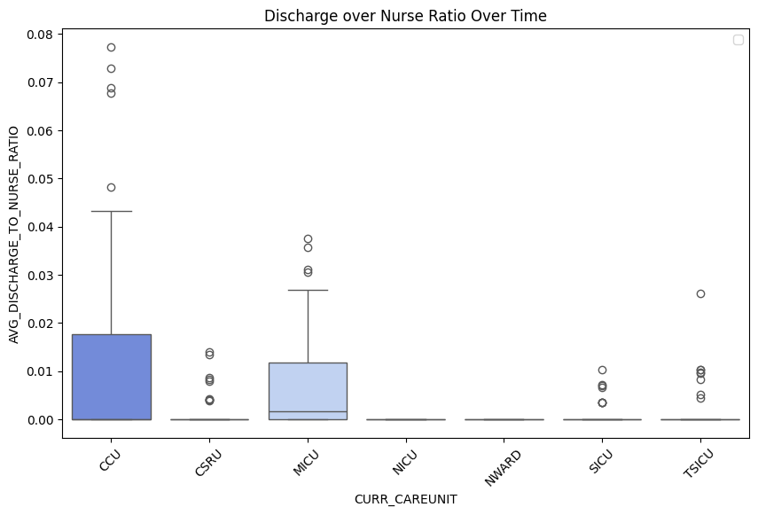

```python
CohortVisualizer.box_plot(
    df=discharge_ratio,
    x="CURR_CAREUNIT",
    y="AVG_DISCHARGE_TO_NURSE_RATIO",
    title="Discharge over Nurse Ratio Over Time",
    save_path=base_save+"Discharge_Nurse_Ratio_box.png"
)
```

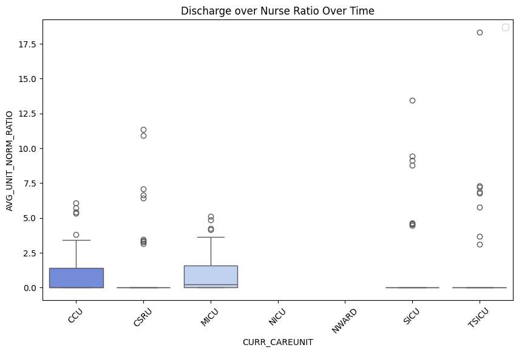

```python
CohortVisualizer.box_plot(
    df=discharge_ratio,
    x="CURR_CAREUNIT",
    y="AVG_UNIT_NORM_RATIO",
    title="Discharge over Nurse Ratio Over Time",
    save_path=base_save+"Discharge_Nurse_Norm_Ratio_box.png"
)
```

Interesting below, we se that within our cohort, we do not see any discharges across units within the first 4 hour time frame for patients in our cohort. However, this changes over the second and third 4 hours.

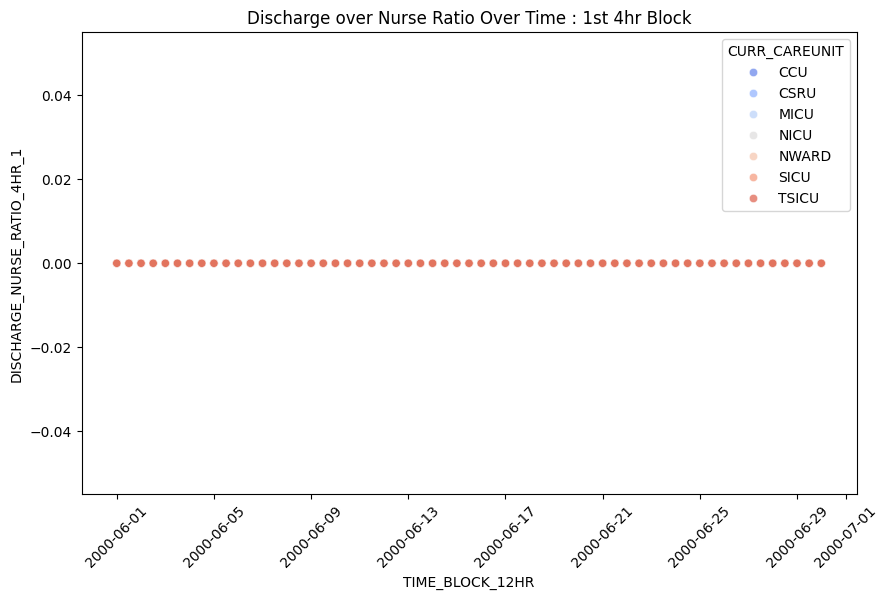

```python
CohortVisualizer.scatter_plot(
    df=discharge_ratio,
    x="TIME_BLOCK_12HR",
    y="DISCHARGE_NURSE_RATIO_4HR_1",
    hue="CURR_CAREUNIT",
    title="Discharge over Nurse Ratio Over Time : 1st 4hr Block",
    save_path=base_save+"Discharge_Nurse_Ratio_4hr_Block1.png"
)
```

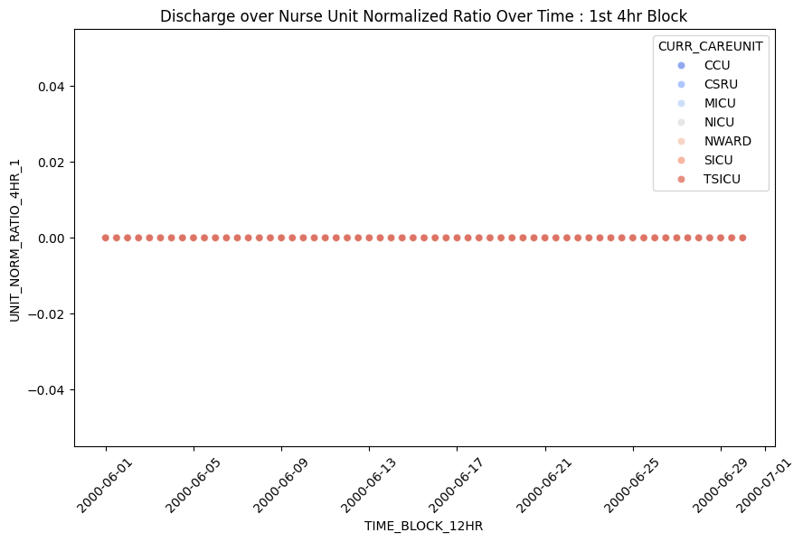

```python
CohortVisualizer.scatter_plot(
    df=discharge_ratio,
    x="TIME_BLOCK_12HR",
    y="UNIT_NORM_RATIO_4HR_1",
    hue="CURR_CAREUNIT",
    title="Discharge over Nurse Unit Normalized Ratio Over Time : 1st 4hr Block",
    save_path=base_save+"Discharge_Nurse_Ratio_Norm_4hr_Block1.png"
)
```

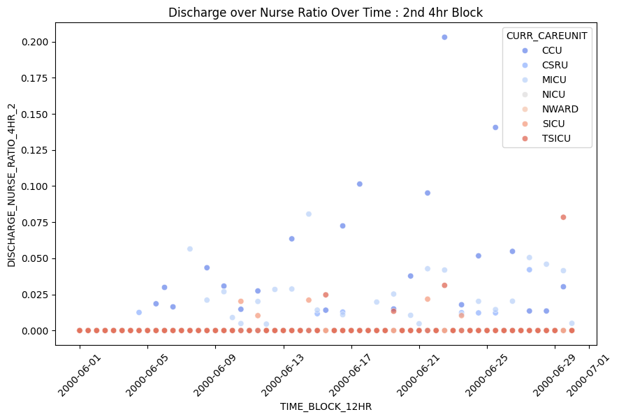

```python
CohortVisualizer.scatter_plot(
    df=discharge_ratio,
    x="TIME_BLOCK_12HR",
    y="DISCHARGE_NURSE_RATIO_4HR_2",
    hue="CURR_CAREUNIT",
    title="Discharge over Nurse Ratio Over Time : 2nd 4hr Block",
    save_path=base_save+"Discharge_Nurse_Ratio_4hr_Block2.png"
)
```

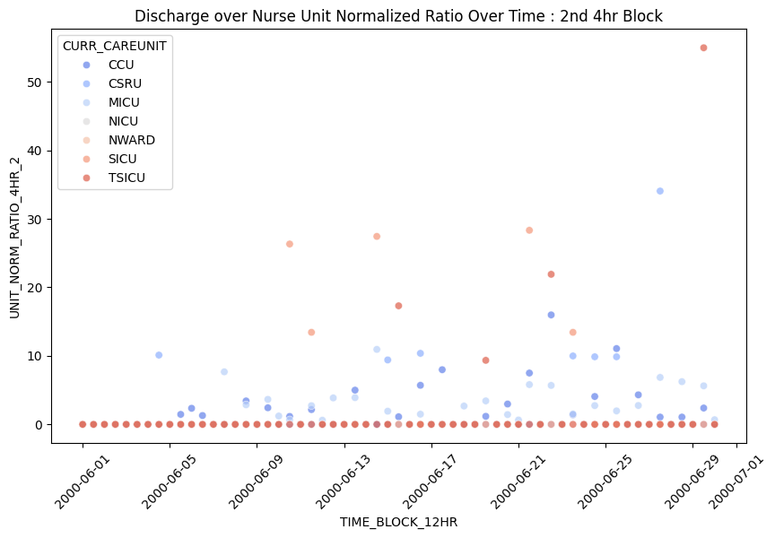

```python
CohortVisualizer.scatter_plot(
    df=discharge_ratio,
    x="TIME_BLOCK_12HR",
    y="UNIT_NORM_RATIO_4HR_2",
    hue="CURR_CAREUNIT",
    title="Discharge over Nurse Unit Normalized Ratio Over Time : 2nd 4hr Block",
    save_path=base_save+"Discharge_Nurse_Ratio_Norm_4hr_Block1.png"
)
```

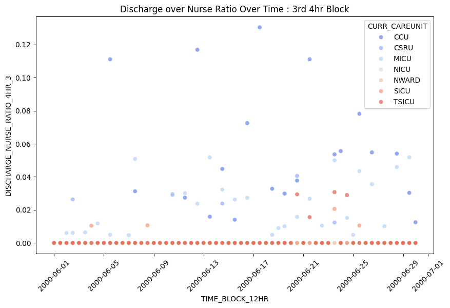

```python
CohortVisualizer.scatter_plot(
    df=discharge_ratio,
    x="TIME_BLOCK_12HR",
    y="DISCHARGE_NURSE_RATIO_4HR_3",
    hue="CURR_CAREUNIT",
    title="Discharge over Nurse Ratio Over Time : 3rd 4hr Block",
    save_path=base_save+"Discharge_Nurse_Ratio_4hr_Block3.png"
)
```

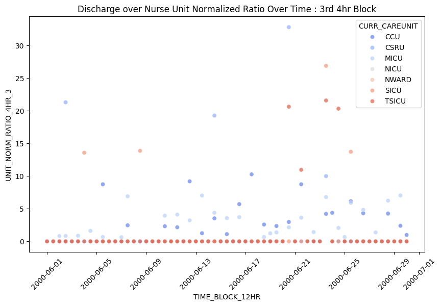

```python
CohortVisualizer.scatter_plot(
    df=discharge_ratio,
    x="TIME_BLOCK_12HR",
    y="UNIT_NORM_RATIO_4HR_3",
    hue="CURR_CAREUNIT",
    title="Discharge over Nurse Unit Normalized Ratio Over Time : 3rd 4hr Block",
    save_path=base_save+"Discharge_Nurse_Ratio_Norm_4hr_Block1.png"
)
```

### Patient Ratio Plots

First, I visualize the number of nurses available over the time frame. This will give me insight into how consistent the nurse availability is within a unit, if there are large fluctuations, if we can see any patterns. There seem to be some slight weekly patterns in increase and decreases in availability, but also, the second 12hr block in each day more often that not, across most units, has less availability that the first 12 hr block for the day.

Also, looking at our patients, it starts of very low in the start of June, and then very quickly ticks up (which we also see this impact in the ratio plots). We can also see that as our patient count in the CCU vastly increases, so do the SICU and TSICU. Which makes sense when considering more patients may be comming into a cardiac unit, and then with severe enough complication, would need to be transferred to those units after initial evaluation and testing for a surgical procedure.

When we look at our Nurse to patient ratio, this gives us a different picture in regards to the overall workload nurse may face across times in different units. Now this is particulary subset to our cohort, which is filtered for Heart Failure and Cardiac Dysfunction. Based on this data, we see a high amount of Nurses available in the NICU ward, but an overall lower amount of patients were admitted into that care unit. Though there may be many nurses in that unit, they are likely treating other ICD9 coded related issues. If we are interested in focusing on Nurses that have experiences or perpectives on treatment of our patients in our specialized cohort groups, we can use this to inform what the best units to go to would be, scuh aas the CCU and MICU. The CCU and MICU has very low ratios, showing that in regards to patients in our cohort, most of them reside in higher rates in those two units.

```python
nurse_unit_summary = expanded_nurses_df.groupby(by=['CURR_CAREUNIT', 'TIME_BLOCK_12HR']).agg('CGID').count().reset_index().rename(columns={'CGID': 'NURSE_COUNT'})
```

```python
patient_unit_summary = expanded_patients_df.groupby(by=['CURR_CAREUNIT', 'TIME_BLOCK_12HR']).agg('SUBJECT_ID').count().reset_index().rename(columns={'SUBJECT_ID': 'SUBJECT_COUNT'})
```

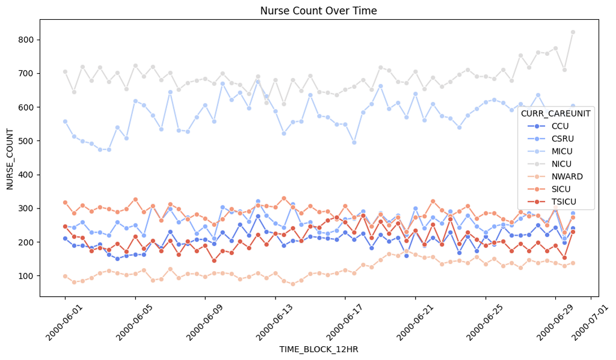

```python
CohortVisualizer.line_plot(
    df=nurse_unit_summary,
    x="TIME_BLOCK_12HR",
    y="NURSE_COUNT",
    hue="CURR_CAREUNIT",
    title="Nurse Count Over Time",
    save_path=base_save+"Nurse_count_Time.png"
)
```

[figure not shown]

```python
CohortVisualizer.line_plot(
    df=patient_unit_summary,
    x="TIME_BLOCK_12HR",
    y="SUBJECT_COUNT",
    hue="CURR_CAREUNIT",
    title="Nurse Count Over Time",
    # save_path=base_save+"Patient_count_Time.png"
)
```

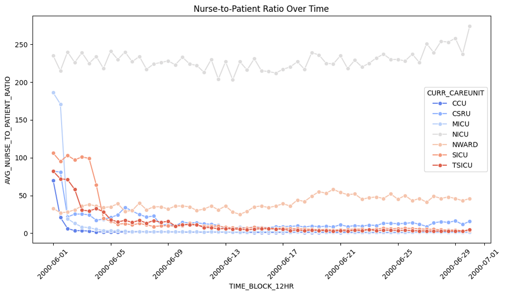

```python
CohortVisualizer.line_plot(
    df=patient_ratio,
    x="TIME_BLOCK_12HR",
    y="AVG_NURSE_TO_PATIENT_RATIO",
    hue="CURR_CAREUNIT",
    title="Nurse-to-Patient Ratio Over Time",
    save_path=base_save+"Patient_Nurse_Ratio.png"
)
```

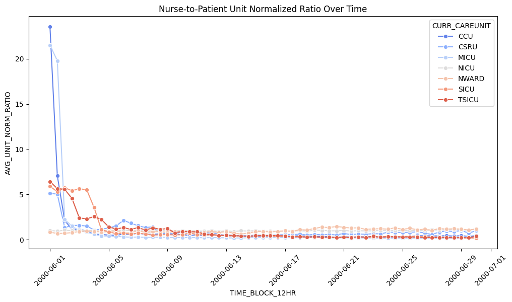

```python
CohortVisualizer.line_plot(
    df=patient_ratio,
    x="TIME_BLOCK_12HR",
    y="AVG_UNIT_NORM_RATIO",
    hue="CURR_CAREUNIT",
    title="Nurse-to-Patient Unit Normalized Ratio Over Time",
    save_path=base_save+"Patient_Nurse_Ratio_Norm.png"
)
```

[figure not shown]

```python
CohortVisualizer.box_plot(
    df=patient_ratio,
    x="CURR_CAREUNIT",
    y="AVG_NURSE_TO_PATIENT_RATIO",
    hue="CURR_CAREUNIT",
    title="Nurse-to-Patient Unit Normalized Ratio Over Time",
    save_path=base_save+"Patient_Nurse_Ratio_box.png"
)
```

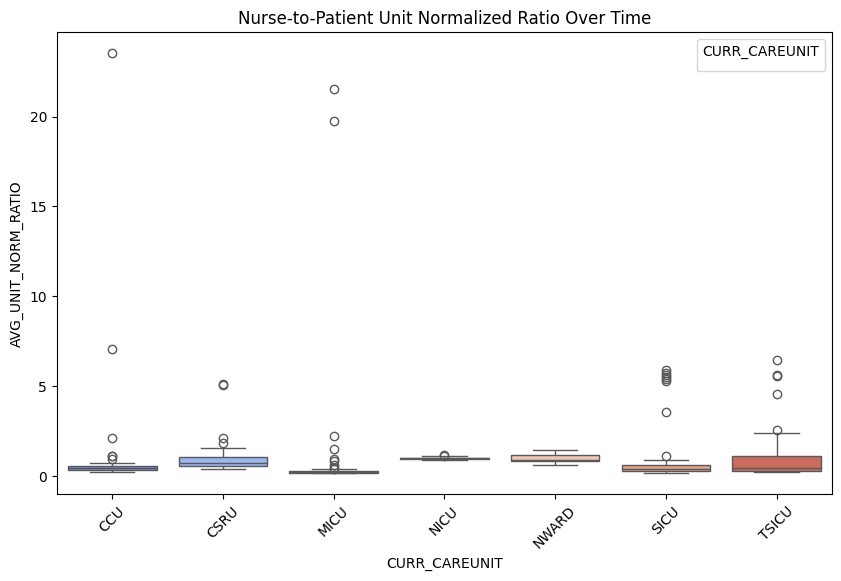

```python
CohortVisualizer.box_plot(
    df=patient_ratio,
    x="CURR_CAREUNIT",
    y="AVG_UNIT_NORM_RATIO",
    hue="CURR_CAREUNIT",
    title="Nurse-to-Patient Unit Normalized Ratio Over Time",
    save_path=base_save+"Patient_Nurse_Ratio_Norm_box.png"
)
```

### Lab Result Plots

In general, we see much more tests for Troponin in our patient cohort, rather than BNP. Most out our Troponin tests are quite low in comparison to the entire cohort, but the BNP levels are quite flat but very high.

From researching about the tests, it looks as if Troponin tests are utilized to consistently monitor myocardial infarctions and their severities, so it would give insight to an injury and how bad it is. It is measured from cardiomyocytes that are damaged in the heart muscle cells. Troponin is a good measure of short-term morbidity, so it seems likely that the test would be conducted more frequntly to patients entering units with severw complications.

BNP is is produced by the heart's ventricles from an increase in pressure or volume overload. It also raises from cardiac stress, but then returns to normal is some hours. BNP provides insight into longer term cardiac problems, and may not be as helpful information for immediate complications. When looking at the test values for BNP, the MICU has the highest tests and values, which makes sense considering it is a intensive care unit.

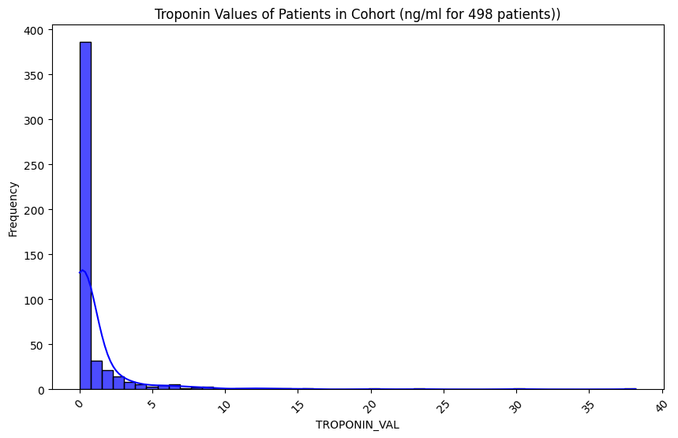

```python
CohortVisualizer.histogram(
    df=latest_troponin,
    column="TROPONIN_VAL",
    bins= 50,
    title=f"Troponin Values of Patients in Cohort ({latest_troponin['TROPONIN_UNIT'].unique()[0]} for {latest_troponin['TROPONIN_VAL'].count()} patients))",
    save_path=base_save+"Troponin_Histogram.png"
)
```

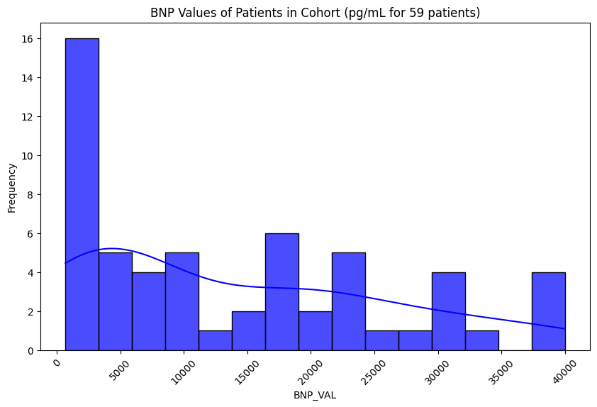

```python
CohortVisualizer.histogram(
    df=latest_bnp,
    column="BNP_VAL",
    bins= 15,
    title=f"BNP Values of Patients in Cohort ({latest_bnp['BNP_UNIT'].unique()[-1]} for {latest_bnp['BNP_UNIT'].count()} patients)",
    save_path=base_save+"BNP_Histogram.png"
)
```

```python
# get the last row for each patiend and HADM_ID and keep CURR_CAREUNIT
last_patient_unit = expanded_patients_df.sort_values(by=['SUBJECT_ID', 'HADM_ID', 'TIME_BLOCK_12HR']).groupby(['SUBJECT_ID', 'HADM_ID']).tail(1)
# merge with latest troponin and bnp
last_patient_unit = last_patient_unit.merge(latest_troponin, on=['SUBJECT_ID'], how='left')
last_patient_unit = last_patient_unit.merge(latest_bnp, on=['SUBJECT_ID'], how='left')
```

```python
test_unitsummary= last_patient_unit.groupby(by = ['CURR_CAREUNIT']).count().reset_index().rename(columns={'SUBJECT_ID': 'PATIENT_COUNT','TROPONIN_VAL':'Troponin_Count','BNP_VAL':'BNP_Count'})
```

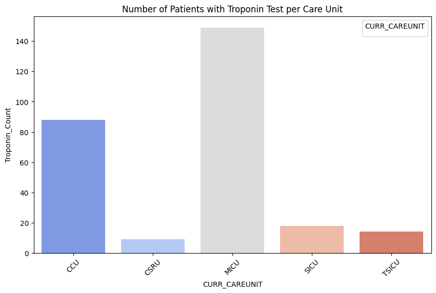

```python
CohortVisualizer.bar_plot(
    df=test_unitsummary,
    x="CURR_CAREUNIT",
    y="Troponin_Count",
    hue="CURR_CAREUNIT",
    title="Number of Patients with Troponin Test per Care Unit",
    save_path=base_save+"Troponin_CareUnit_bar.png"
)
```

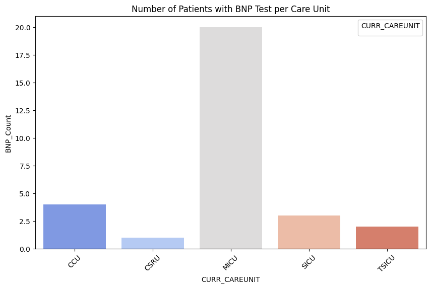

```python
CohortVisualizer.bar_plot(
    df=test_unitsummary,
    x="CURR_CAREUNIT",
    y="BNP_Count",
    hue="CURR_CAREUNIT",
    title="Number of Patients with BNP Test per Care Unit",
    save_path=base_save+"BNP_CareUnit_bar.png"
)
```

# Output Summary

## Content Naming and Location

Outputs; including log files, intermdiate data tables, and visuals can be found in the Output folders in the repository.